# writeup

```python
import matplotlib.image as mpimg
import matplotlib.pyplot as plt
import numpy as np
import cv2
from util import *
from sklearn.cross_validation import train_test_split
from sklearn.svm import LinearSVC
from sklearn.preprocessing import StandardScaler
import time
from joblib import Memory
from scipy.ndimage.measurements import label
import pickle

%load_ext autoreload
%autoreload 2
%matplotlib inline
%pylab inline
pylab.rcParams['figure.figsize'] = (10, 6)
```

```
The autoreload extension is already loaded. To reload it, use:
  %reload_ext autoreload
```

```python
memory = Memory(cachedir='cache')
```

## Pipeline

Our pipeline of vehicle detection will is as follows:

- Load a train/test dataset
- Extract features from train dataset
- Train a classifier
- Find regions of interest using a rolling window technique in camera frame
- Reduce impact of false positives using heatmap
- Join detected regions and draw boxes as the result to video file

## Train dataset

Train dataset comprised from images proposed in lectures as follows: "... images taken from the GTI vehicle image database, the KITTI vision benchmark suite, and examples extracted from the project video itself..."

The dataset contains two groups of images: cars and everything else.

```python
cars = traverse_train_dataset('vehicles', ['GTI_Far', 'GTI_Left', 'GTI_MiddleClose', 'GTI_Right', 'KITTI_extracted'])
notcars = traverse_train_dataset('non-vehicles', ['Extras', 'GTI'])

data_info = data_look(cars, notcars)
```

The dataset contains

```python
data_info["n_cars"]
```

```
8792
```

car images and

```python
data_info["n_notcars"]
```

```
8968
```

of not car images. Image shape is:

```python
data_info["image_shape"]
```

```
(64, 64, 3)
```

Example images of both classes:

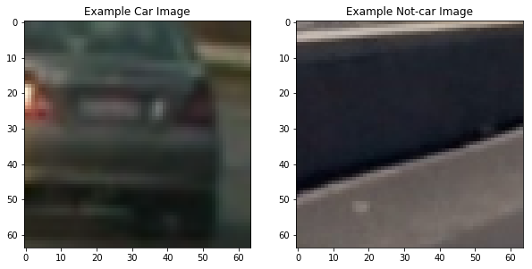

```python
car_ind = np.random.randint(0, len(cars))
notcar_ind = np.random.randint(0, len(notcars))

car_image = mpimg.imread(cars[car_ind])
notcar_image = mpimg.imread(notcars[notcar_ind])

# Plot the examples
fig = plt.figure()
plt.subplot(121)
plt.imshow(car_image)
plt.title('Example Car Image')
plt.subplot(122)
plt.imshow(notcar_image)
plt.title('Example Not-car Image')
```

As can be seen, the dataset contains close and big enough number of samples which makes it balanced and there're no need for additional imbalance reduction. However more data for train won't hurt (but overfit can be a problem).

## Feature extraction

Our classification algorithm (linear binary SVM in this case) must learn to distinguish between two classes. Since car images must definitely have some shared features, it must differentiate them from the "noise" of the non-car images. These features are:

- Color
- Shape

While images of the same car model can differ in color, it seems that shape detection must be a more robust classifier, but the classifier trained on a finite set of all possible car paint colors can add some weight.

In order to detect color features, we convert our RGB images to YCrCb colorspace, where Y is the grayscale copy of the image, while other two channels contain a base color variation. Since Y-channel contains the exact greyscale pixels of the pattern it can add weight in case of exact match while color channels can help in exact color detection.

Car images definetely have some shape that can be detected, while unordered dataset of random world objects must not have any particular shape and we assume it's "noisy". For shape pattern extraction we use so called Histogram of Gradients (or HOG) tecnique.

### Preprocessing

Since our classifier knows nothing about the nature of the data, we must produce a compatible input for it. SVM classifier accepts a 2D vector of train samples where each row will contain concatenated:

- Spatial features. This feature vector contains all three color channels of the source image resized to fixed shape 32x32.
- Color histogram. Here we compute the histogram of values in each color channel using 32 bins and concatenate all of them in order.
- HOG features. Here we split our image to cells of 8x8 shape and using sliding window approach compute the gradients (direction of pixel value change) inside the blocks comprised of 2 cells. For each such cell we get a vector of 9 orientations (angle=360/9). We do that for each color channel separately and concatenate the result.

Demonstration of each step in preprocessing pipeline:

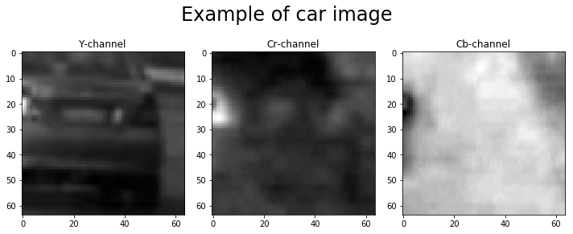

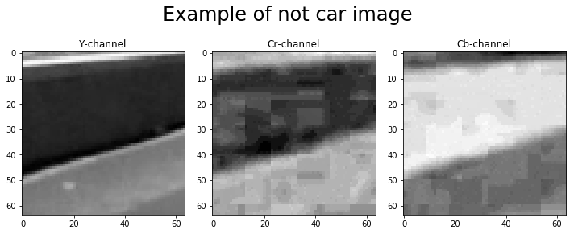

```python
def plot_channels(img, title):
    fig, axarr = plt.subplots(1, 3)

    fig.suptitle(title, fontsize=24)

    axarr[0].imshow(img[:,:,0], cmap='gray')
    axarr[0].set_title('Y-channel')

    axarr[1].imshow(img[:,:,1], cmap='gray')
    axarr[1].set_title('Cr-channel')

    axarr[2].imshow(img[:,:,2], cmap='gray')
    axarr[2].set_title('Cb-channel')

    fig.tight_layout()
    fig.subplots_adjust(top=1.2)

car_image_ycrcb = cv2.cvtColor(car_image, cv2.COLOR_RGB2YCrCb)
notcar_image_ycrcb = cv2.cvtColor(notcar_image, cv2.COLOR_RGB2YCrCb)

plot_channels(car_image_ycrcb, 'Example of car image')
plot_channels(notcar_image_ycrcb, 'Example of not car image')
```

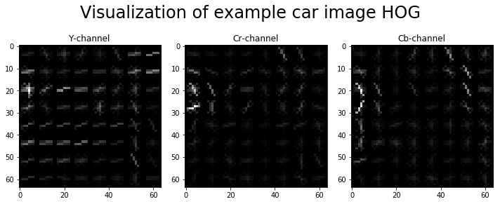

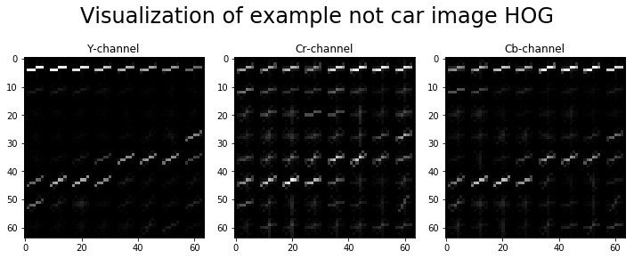

```python
orient = 9
spatial_size = (32, 32)
pix_per_cell = 8
cell_per_block = 2

_, car_hog1 = get_hog_features(car_image_ycrcb[:,:,0], orient, pix_per_cell, cell_per_block, vis=True, feature_vec=False)
_, car_hog2 = get_hog_features(car_image_ycrcb[:,:,1], orient, pix_per_cell, cell_per_block, vis=True, feature_vec=False)
_, car_hog3 = get_hog_features(car_image_ycrcb[:,:,2], orient, pix_per_cell, cell_per_block, vis=True, feature_vec=False)

_, notcar_hog1 = get_hog_features(notcar_image_ycrcb[:,:,0], orient, pix_per_cell, cell_per_block, vis=True, feature_vec=False)
_, notcar_hog2 = get_hog_features(notcar_image_ycrcb[:,:,1], orient, pix_per_cell, cell_per_block, vis=True, feature_vec=False)
_, notcar_hog3 = get_hog_features(notcar_image_ycrcb[:,:,2], orient, pix_per_cell, cell_per_block, vis=True, feature_vec=False)

plot_channels(np.dstack([car_hog1, car_hog2, car_hog3]), 'Visualization of example car image HOG')
plot_channels(np.dstack([notcar_hog1, notcar_hog2, notcar_hog3]), 'Visualization of example not car image HOG')
```

## Train classifier

Linear binary SVM classifier was choosen for the task. All three feature sources were used. The length of concatenated feature vector for each image is 8460 and has the following format:

- spatial: size=32x32x3=3072, cells=[0; 3072)
- histogram: size=32x3=96, cells=[3072; 3168)
- HOG: size=1764x3=5292, cells=[3168; 8460)

As can be seen from the following figure, HOG features (x>3168) have by magnitude more impact on classification.

```python
svc = pickle.load(open('svc.p', 'rb'))
X_scaler = pickle.load(open('scaler.p', 'rb'))
```

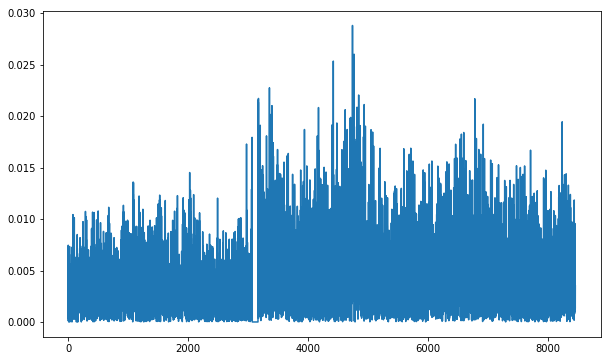

```python
plt.plot(np.abs(svc.coef_.ravel()))
```

Figure below shows top 20 most important vector elements that have impact on positive and negative class detection.

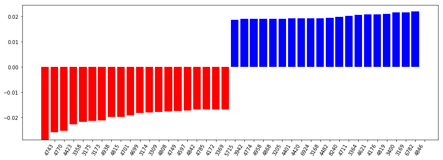

```python
# credits: https://medium.com/@aneesha/visualising-top-features-in-linear-svm-with-scikit-learn-and-matplotlib-3454ab18a14d#.3umog117e
def plot_coefficients(classifier, feature_names, top_features=20):
    coef = classifier.coef_.ravel()
    top_positive_coefficients = np.argsort(coef)[-top_features:]
    top_negative_coefficients = np.argsort(coef)[:top_features]
    top_coefficients = np.hstack([top_negative_coefficients, top_positive_coefficients])
    # create plot
    plt.figure(figsize=(15, 5))
    colors = ['red' if c < 0 else 'blue' for c in coef[top_coefficients]]
    plt.bar(np.arange(2 * top_features), coef[top_coefficients], color=colors)
    feature_names = np.array(feature_names)
    plt.xticks(np.arange(1, 1 + 2 * top_features), feature_names[top_coefficients], rotation=60, ha='right')
    plt.show()

plot_coefficients(svc, range(0, 8460))
```

## Sliding window search

A simple exhausive sliding window search technique helps apply the classifier to each fixed region of the image.

```python
test_images = [mpimg.imread(f) for f in glob.glob('test_images/*.jpg')]

test_image = test_images[4]

conv = cv2.COLOR_RGB2YCrCb
orient = 9
spatial_size = (32, 32)
pix_per_cell = 8
cell_per_block = 2
hist_bins = 32
ystart = 400
ystop = 656

test_image_work = test_image[ystart:ystop,:,:]
```

Sliding window search is implemented with different step sizes and on different scales. For example, here is our test image. The intersection of horizontal/vertical lines on the blue grid layer shows the top/left positions of each window. Region of interest is bounded by y coordinate [400; 656] in order to reduce amount of unnecessary calculations.

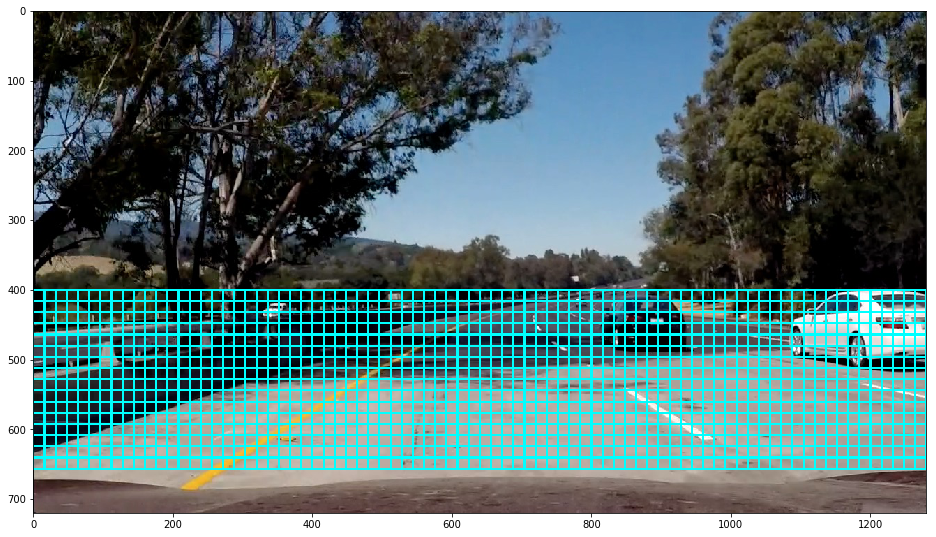

```python
windows = slide_window(test_image, ystart, ystop, pix_per_cell, cell_per_block, scale=1)
plt.figure(figsize=(16, 12))
plt.imshow(draw_boxes(test_image, windows, (0, 255, 255), thick=2))
```

As has been said, sliding image search consequentially extracts windows on several grid scales. The next figure illustrates the search with scale 2 (cell width/height doubled). Here red box denotes window number 91 and the yellow one window number 92 next to it.

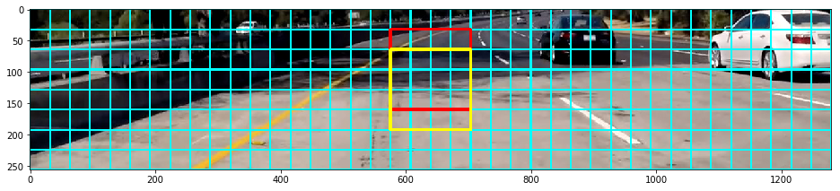

```python
windows_scale_2 = slide_window(test_image_work, 0, ystop - ystart, pix_per_cell, cell_per_block, scale=2)

test_image_work_net = draw_boxes(test_image_work, windows_scale_2, color=(0, 255, 255), thick=2)
test_image_work_net_91 = draw_boxes(test_image_work_net, [windows_scale_2[91]], color=(255, 0, 0), thick=4)
test_image_work_net_91_92 = draw_boxes(test_image_work_net_90, [windows_scale_2[92]], color=(255, 255, 0), thick=4)

plt.figure(figsize=(16, 12))
plt.imshow(test_image_work_net_90_91)
```

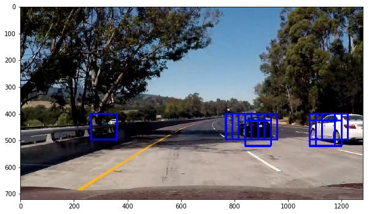

```python
car_boxes = find_cars(test_image,
    svc=svc,
    X_scaler=X_scaler,
    scale=1.5,
    conv=conv,
    orient=orient,
    spatial_size=spatial_size,
    pix_per_cell=pix_per_cell,
    cell_per_block=cell_per_block,
    hist_bins=hist_bins,
    ystart=ystart,
    ystop=ystop
)

plt.imshow(visualize_found_cars(test_image, car_boxes))
```

Windows search repeated on different scales. Next figure illustrates how classifier detects car patters on scales [1, 1.5, 2, 2.5, 3, 3.5, 4].

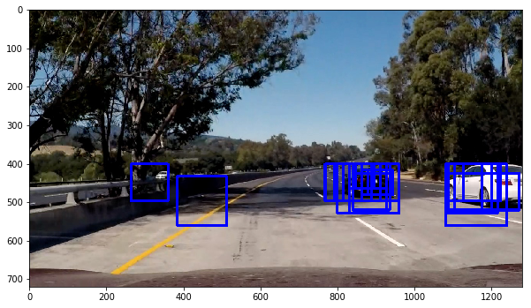

```python
car_boxes = find_cars_multiscaled(test_image,
    scales=scale_steps(1, 4, 0.5),
    svc=svc,
    X_scaler=X_scaler,
    conv=conv,
    orient=orient,
    spatial_size=spatial_size,
    pix_per_cell=pix_per_cell,
    cell_per_block=cell_per_block,
    hist_bins=hist_bins,
    ystart=ystart,
    ystop=ystop
)

plt.imshow(visualize_found_cars(test_image, car_boxes))
```

Seems that number of false positives also increases.

## Heatmaps for bounding boxes

The resulting image must contain one bounding box for each car detected on the picture. One possible way to achieve that is to use heatmaps. The techinique is simple: each pixel on the image inside every box gets +1 to color value. If we apply a threshold then we also can get rid of some false positives. Here's the example of such heatmap with threshold=1 applied.

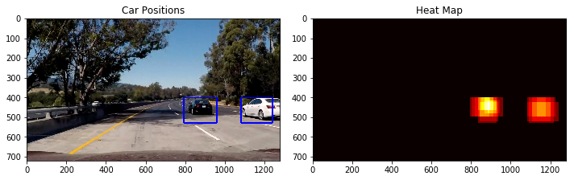

```python
plot_annotate_and_heatmap(test_images[4],
    thresh=1,
    scales=scale_steps(1, 4, 0.5),
    svc=svc,
    X_scaler=X_scaler,
    conv=conv,
    orient=orient,
    spatial_size=spatial_size,
    pix_per_cell=pix_per_cell,
    cell_per_block=cell_per_block,
    hist_bins=hist_bins,
    ystart=ystart,
    ystop=ystop
)
```

A function scipy.ndimage.measurements.label() applied to the resulting heatmap identifies individual blobs.

Some additional approaches were applied in order to reduce the number of false positeves on final video:

- Heatmaps of 5 consecutive video frames were merged together. That allowed to drop out false positives appearing on less then 5 frames in the same region of the picture.
- Sometimes smaller car patterns were detected but larger were not. These small windows appeared close to each other but not connected. Thus car pattern was detected partly. The following technique was applied to reduce this effect: a bounding box of each detected window was expaned by 25 px in each direction. The overlapping boxes then merged together to get a bigger bounding box that included smaller boxes.

Result window can be found by this link: https://www.youtube.com/watch?v=GdLnVTX9WrQ

## Discussion

I'm pretty satisfied with the result, but I'm sure there are many opportunities for improvement. Sometimes the classifier fails to detect the car on the next video frame. That produces a raggy bounding box and sometimes it can even disappear. A real life object cannot suddenly disapear from the image. I think a kind of transition algorithm can be applied to smooth movements of bounding boxes that can also add some delay before removing boxes from the image.

Also I've noticed that the white car was significally harder detected by the classifier. I think this is because our train dataset was not big enough. A bigger dataset would greatly improve the precision. A different kind of classifier that suits more for image pattern detection such as Neural Network definitely would improve the precision too.